# Species change at pixel level

```r
library(tidyverse)
library(terra)
library(sf)
library(rnaturalearth)
library(here)
library(iucnredlist) ### remotes::install_github("IUCN-UK/iucnredlist")
library(janitor)
```

# See how species change at the pixel level

# Will create a map of Soresen’s Similiarity Index at the pixel level

```r
# Functions
source(here("common_fxns.R"))
```

```r
# Read in Lawler data
spp_mapfiles <- list.files(here_anx('/data_lawler_2020/species_projections'),
                           full.names = TRUE, recursive = TRUE, pattern = '.tif')
spp_all_df <- data.frame(f = spp_mapfiles,
                         spp = basename(spp_mapfiles) %>%
                           str_remove('(_gf85|_in85|_mc85|_bias).+') %>%
                           str_replace_all('_', ' '),
                         tax = basename(dirname(spp_mapfiles)))
```

```r
# Read in AVONET dataset (reading in BirdLife tab, which should match with IUCN names)
avonet <- read_csv(here("data-laa", "AVONET-birdlife-tab-supplementary-dataset-1.csv")) %>%
  clean_names()
```

```r
# Filter for just Lawler birds
birds_all_df <- spp_all_df %>%
  filter(tax == "Birds")
```

```r
birds_all <- birds_all_df %>%
  group_by(spp, tax) %>%
  summarize(files = n())
```

## Gather maps and aggregate

Following the method in 2_combine_spp_scenarios.qmd: For all the Lawler birds species (301) gather all future scenario maps and aggregate, summing and dividing by 3 to make a “probability” map for future distributions, and crop to just the lower 48 US states (and a little Canada and Mexico). Then crop the historical maps to the same extent.

### Aggregate future projections

For each species in the sample, aggregate the three future scenarios into a single map. Crop to the lower continental US states.

```r
### set up extent for continental US
us_extent <- ext(c(xmin = -130, xmax = -65, ymin = 23, ymax = 50))

### Aggregate over the vector of species names
spp_vec <- birds_all_df$spp %>% unique()

future_rast <- lapply(spp_vec, FUN = agg_scenario, df = birds_all_df) %>%
  setNames(spp_vec) %>%
  rast()

x <- future_rast[[1]]
#plot(x, main = names(future_rast)[1])
```

### crop historical maps

```r
hist_rast <- lapply(spp_vec, FUN = agg_scenario, df = birds_all_df,
                    scenario = 'historical') %>%
  setNames(spp_vec) %>%
  rast()

x <- hist_rast[[1]]
#plot(x, main = names(hist_rast)[1])
```

## Generate jurisdiction map

Let’s generate a simple jurisdiction map - US states, and Canada and Mexico.

```r
states_sf <- ne_states(returnclass = 'sf', country = c('Mexico', 'Canada', 'United States of America'))

state_id_df <- states_sf %>%
  st_drop_geometry() %>%
  mutate(juris = ifelse(adm0_a3 == 'USA', name, admin)) %>%
  dplyr::select(id = gn_id, juris)
### plot(states_sf %>% select(iso_a2))
states_rast <- rasterize(states_sf, hist_rast, field = 'gn_id')
#plot(states_rast)
```

```r
# Function to get pixels instead of jurisdictions
extract_jurisdictions_pixels <- function(spp, future_r, hist_r, juris_r) {
  ### spp <- spp_vec[1]
  ### future_r = future_rast; hist_r = hist_rast; juris_r = states_rast
  s_f_r <- future_r[[names(future_r) == spp]]
  s_h_r <- hist_r[[names(hist_r) == spp]]
  s_df <- data.frame(values(s_h_r),
                     values(s_f_r),
                     values(juris_r)) %>%
    setNames(c('historical', 'future', 'id')) %>%
    mutate(pixel_id = row_number()) %>%
    filter(!is.na(id)) %>%
    filter(!is.na(historical) | !is.na(future)) #%>%
    #group_by(id) %>%
    #summarize(n_historical = sum(historical > .25),
              #n_future = sum(future > .5))

  return(s_df)
}
```

## Rough pass at classification?

For each spp let’s create a dataframe of jurisdictions and cell values…

```r
state_spp_list <- lapply(spp_vec, FUN = extract_jurisdictions_pixels,
                         future_r = future_rast,
                         hist_r = hist_rast,
                         juris_r = states_rast) %>%
  setNames(spp_vec) %>%
  bind_rows(.id = 'spp') %>%
  left_join(state_id_df, by = 'id') #%>%
  ### note, Canada and Mexico have multiple jurisdictions (provinces and states)
  ### so sum up all those instances
  #group_by(spp, juris) %>%
  #summarize(n_historical = sum(n_historical),
            #n_future = sum(n_future),
            #.groups = 'drop')
```

# Now that we have each species at the pixel level (pixel id), how many species are in each pixel for historical and future?

```r
pixel_spp <- state_spp_list %>%
  group_by(pixel_id, juris) %>%
  summarize(n_spp_historical = sum(historical > .25),
            n_spp_future = sum(future > .5)) %>%
  mutate(n_spp_diff = n_spp_future - n_spp_historical)
```

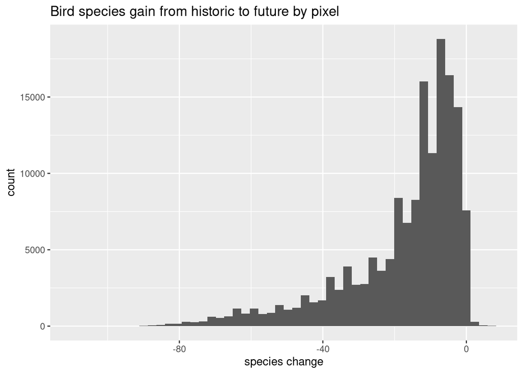

```r
# Vast majority of pixels are losing total # of species (simply from numbers perspective)
ggplot(data = pixel_spp) +
  geom_histogram(aes(x = n_spp_diff),
                 bins = 50) +
  labs(title = "Bird species gain from historic to future by pixel",
       x = "species change")
```

# Next step - sorensen similarity index (test a few pixels)

```r
# Test out with a single pixel (141325)
pxl_141325 <- state_spp_list %>%
  filter(pixel_id == 141325) %>%
  # Assign future pixels > 0.5 to spp prescence
  mutate(future = case_when(future > 0.5 ~ 1,
                           TRUE ~ 0))
```

```r
pxl_si <- pxl_141325 %>%
  group_by(pixel_id) %>%
  summarize(shared = sum(historical == 1 & future == 1),
            historical_spp = sum(historical),
            future_spp = sum(future),
            ssi = (2 *shared)/(historical_spp + future_spp))
```

```r
# Try all pixels
pxl_ssi <- state_spp_list %>%
  # Assign future pixels > 0.5 to spp prescence
  mutate(future = case_when(future > 0.5 ~ 1,
                           TRUE ~ 0)) %>%
  group_by(pixel_id, juris) %>%
  summarize(shared = sum(historical == 1 & future == 1),
            historical_spp = sum(historical),
            future_spp = sum(future),
            ssi = (2 *shared)/(historical_spp + future_spp))
```

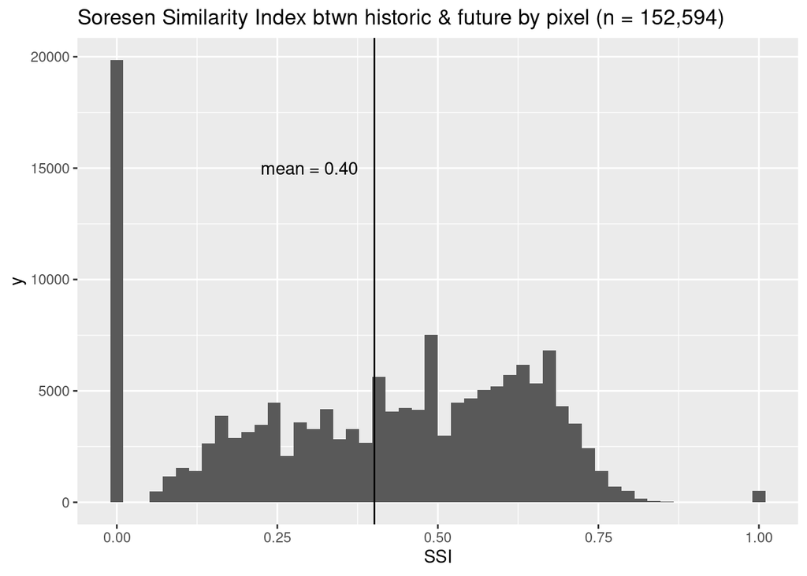

```r
# Distribution of Soresen Similiarity Index for bird species
# Mean is 0.40 (moderate similarity between historic and future)
ggplot(data = pxl_ssi) +
  geom_histogram(aes(x = ssi),
                 bins = 50) +
  geom_vline(xintercept = mean(pxl_ssi$ssi)) +
  annotate("text", label = "mean = 0.40", x = 0.30, y = 15000) +
  #facet_wrap(~juris) +
  labs(title = "Soresen Similarity Index btwn historic & future by pixel (n = 152,594)",
       x = "SSI")
```

```r
# SSI stats by jurisdiction
ssi_juris <- pxl_ssi %>%
  group_by(juris) %>%
  summarize(mean_ssi = mean(ssi),
            median_ssi = median(ssi),
            max_ssi = max(ssi),
            min_ssi = min(ssi)) %>%
  ungroup()
```

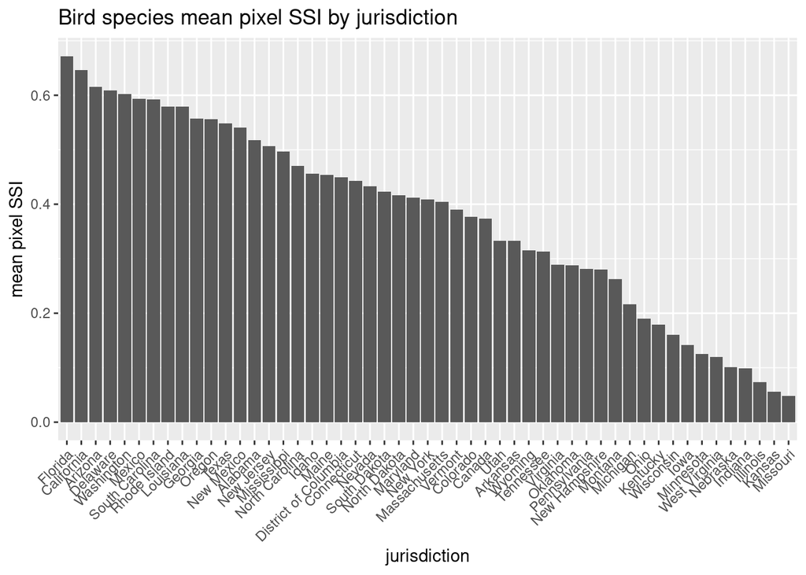

```r
ssi_juris %>%
  mutate(juris = fct_reorder(juris, mean_ssi, .desc = TRUE)) %>%
  ggplot() +
  geom_col(aes(x = juris, y = mean_ssi)) +
  theme(axis.text.x = element_text(angle = 45, vjust = 1, hjust = 1)) +
  labs(y = "mean pixel SSI",
       x = "jurisdiction",
       title = "Bird species mean pixel SSI by jurisdiction")
```

# Create sf of raster ids to map the SSI by pixel

```r
# Create a blank raster with same extent as x = hist_rast[[1]]
id_rast <- rast(x)
```

```r
# Assign IDs and then convert to sf
values(id_rast ) <- 1:ncell(x)
```

```r
id_rast_sf <- id_rast %>%
  stars::st_as_stars() %>%
  st_as_sf() %>%
  rename("pixel_id" = "Acrocephalus familiaris")
```

```r
# Merge in the SSI
id_rast_sf_ssi <- inner_join(id_rast_sf, pxl_ssi)
```

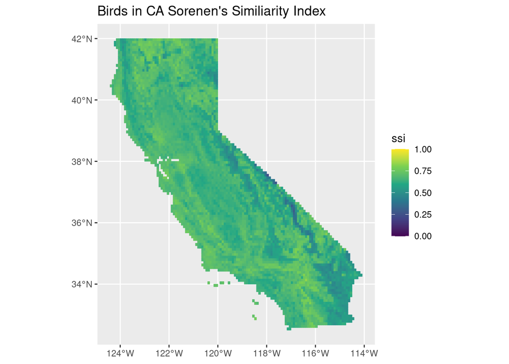

```r
ggplot() +
  geom_sf(data = id_rast_sf_ssi %>%
            filter(juris == "California"), aes(geometry = geometry, fill = ssi, color = ssi), size = 0) +
  scale_fill_viridis_c(limits = c(0,1)) +
  scale_color_viridis_c(limits = c(0,1)) +
  labs(title = "Birds in CA Sorenen's Similiarity Index")
```

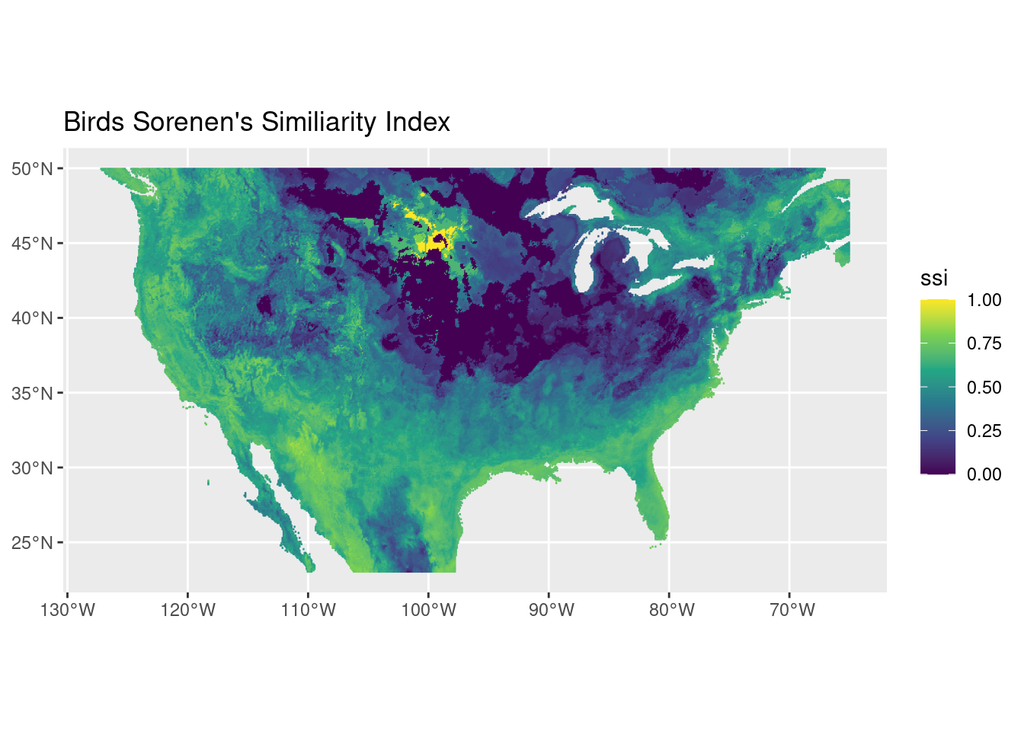

```r
ggplot() +
  geom_sf(data = id_rast_sf_ssi, aes(geometry = geometry, color = ssi, fill = ssi)) +
  scale_color_viridis_c() +
  scale_fill_viridis_c() +
  labs(title = "Birds Sorenen's Similiarity Index")
```

In general, SSI values are as follows (https://www.statology.org/how-to-calculate-and-interpret-the-sorensen-dice-index/):

- 0.80-1.00: Very high similarity (communities share most species)
- 0.60-0.79: High similarity (substantial species overlap)
- 0.40-0.59: Moderate similarity (some shared species)
- 0.20-0.39: Low similarity (few shared species)
- 0.00-0.19: Very low similarity (minimal species overlap)

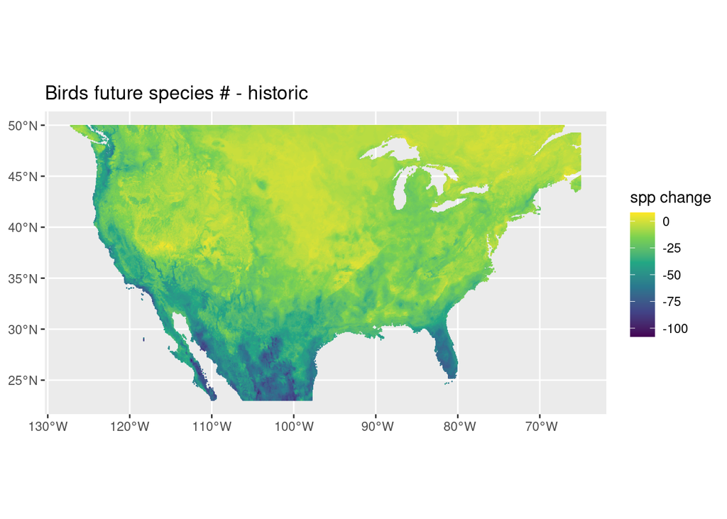

```r
ggplot() +
  geom_sf(data = id_rast_sf_ssi, aes(geometry = geometry, fill = (future_spp - historical_spp), color = (future_spp - historical_spp))) +
  scale_fill_viridis_c() +
  scale_color_viridis_c() +
  labs(title = "Birds future species # - historic",
       fill = "spp change",
       color = "spp change")
```

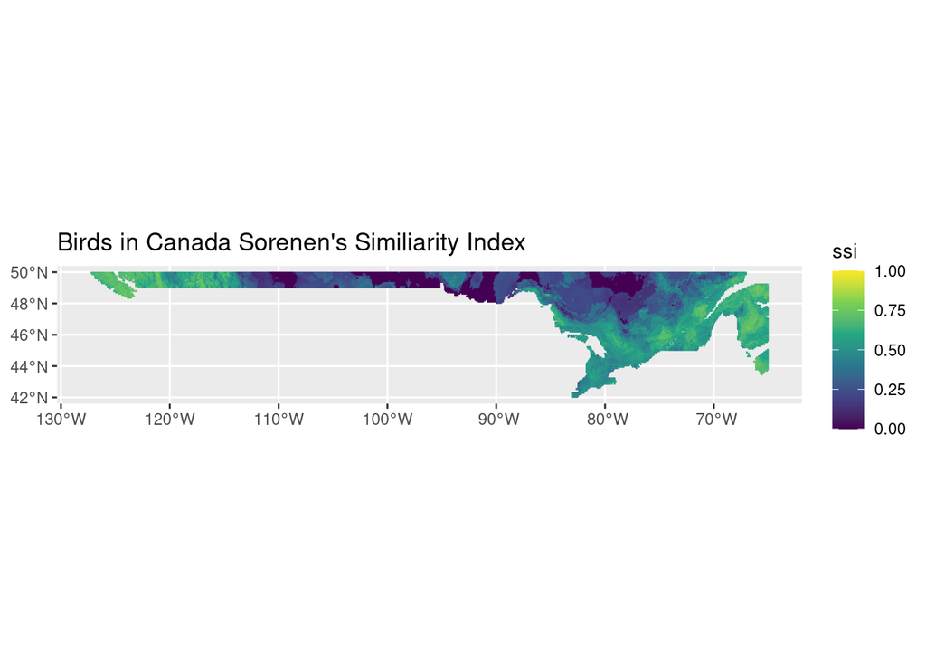

```r
ggplot() +
  geom_sf(data = id_rast_sf_ssi %>%
            filter(juris == "Canada"), aes(geometry = geometry, fill = ssi, color = ssi), size = 0) +
  scale_fill_viridis_c(limits = c(0,1)) +
  scale_color_viridis_c(limits = c(0,1)) +
  labs(title = "Birds in Canada Sorenen's Similiarity Index")
```